# ECE 176 Assignment 2: Linear Regression

### Visualize the filters (10%)

```
Best LR: 0.01
Best Weight Decay: 0.0001
```

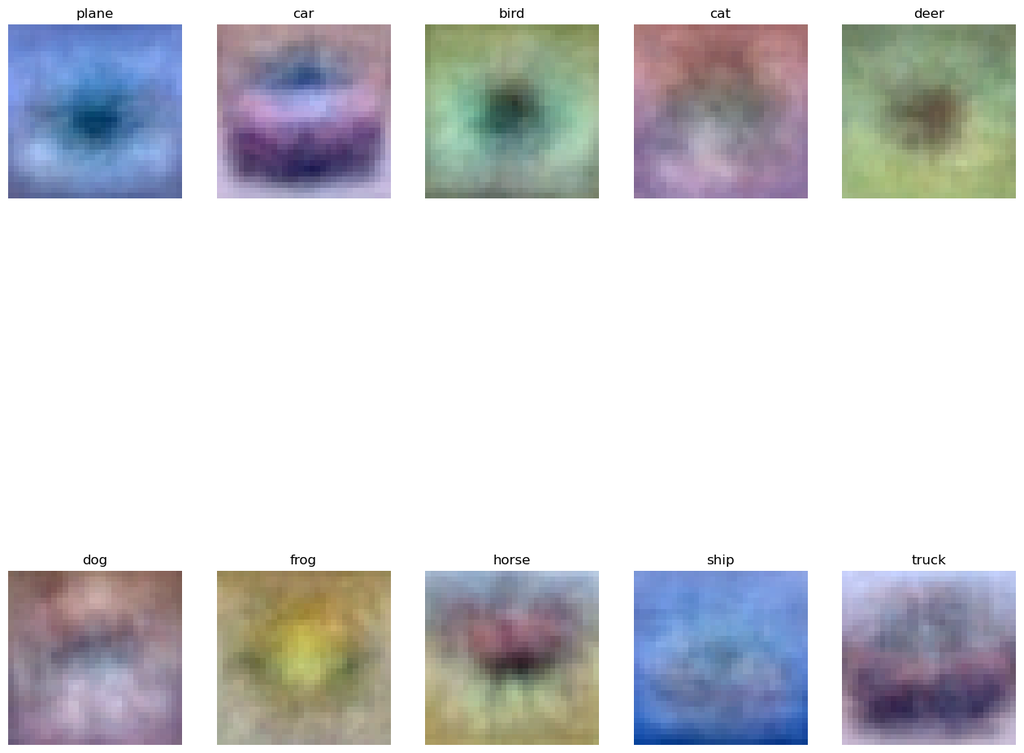

```python
# These visualizations will only somewhat make sense if your learning rate and weight_decay parameters were
# properly chosen in the model. Do your best.

# TODO: Run this cell and Show filter visualizations for the best set of weights you obtain.
# Report the 2 hyperparameters you used to obtain the best model.

# NOTE: You need to set `best_learning_rate` and `best_weight_decay` to the values that gave the highest accuracy
print("Best LR:", best_learning_rate)
print("Best Weight Decay:", best_weight_decay)

# NOTE: You need to set `best_weights` to the weights with the highest accuracy
w = best_weights[:, :-1]
w = w.reshape(10, 3, 32, 32).transpose(0, 2, 3, 1)

w_min, w_max = np.min(w), np.max(w)

fig = plt.figure(figsize=(16, 16))
classes = [
    "plane",
    "car",
    "bird",
    "cat",
    "deer",
    "dog",
    "frog",
    "horse",
    "ship",
    "truck",
]
for i in range(10):
    fig.add_subplot(2, 5, i + 1)

    # Rescale the weights to be between 0 and 255
    wimg = 255.0 * (w[i, :, :, :].squeeze() - w_min) / (w_max - w_min)
    plt.imshow(wimg.astype(int))
    plt.axis("off")
    plt.title(classes[i])
plt.show()
```

#### Inline Question 3. (9%)

a. Compare and contrast the performance of the 2 classifiers i.e. Linear Regression and Logistic Regression. b. Which classifier would you deploy for your multiclass classification project and why?

#### Your Answer:

Linear regression resulted in a higher maximum accuracy at 37.6% compared to logistic regression at 32.8%. When visualizing the filters, the linear regression immages appear brighter and with more definition compared to the more dull but better blended imaged that came from logistic regression. This surprised me as I figured that logistic regression would be more accurate for a multiclass classification project as that is what it's suited for.

## Survey (1%)

### Question:

How many hours did you spend on assignment 2?

### Your Answer:

About 7 hours